# clusteringproj4

### Intro

Increasing revenue is essential to any business. It becomes exponentially easier to increase revenue when you know the habits of your customer base and can group them so you can have custom marketing and other aspects of business for each customer. This both improves the customer experience, cuts down on inefficent spending, and increases revenue. That is why I decided to use a mall customer dataset. I want to cluster the customers based off of their spending habits and demographics so I can then provide them with improved experiences and increase revenue for the business.

### What is Clustering?

Clustering is an unsupervised learning algorithm that uses unlabeled data and groups together similar data points based off of their features. The algorithm looks at the data and finds patterns and puts these data points into clusters based on these similarities. K-Means the one that I will be using works by randomly initializing a certain number of clusters around random centroids. You then assign each data point to the nearest center and then find the mean position of all the points and then assign the new centroid. You then continue this process until the change becomes very infinitesimal

### Data

We will be using a mall customer segmentation dataset that I found off of kaggle. It has plenty of features that will help me derive data driven insights to improve the business. Some of these include demographic information such as age or gender. We also have annual income and spending score.

### Data Understanding

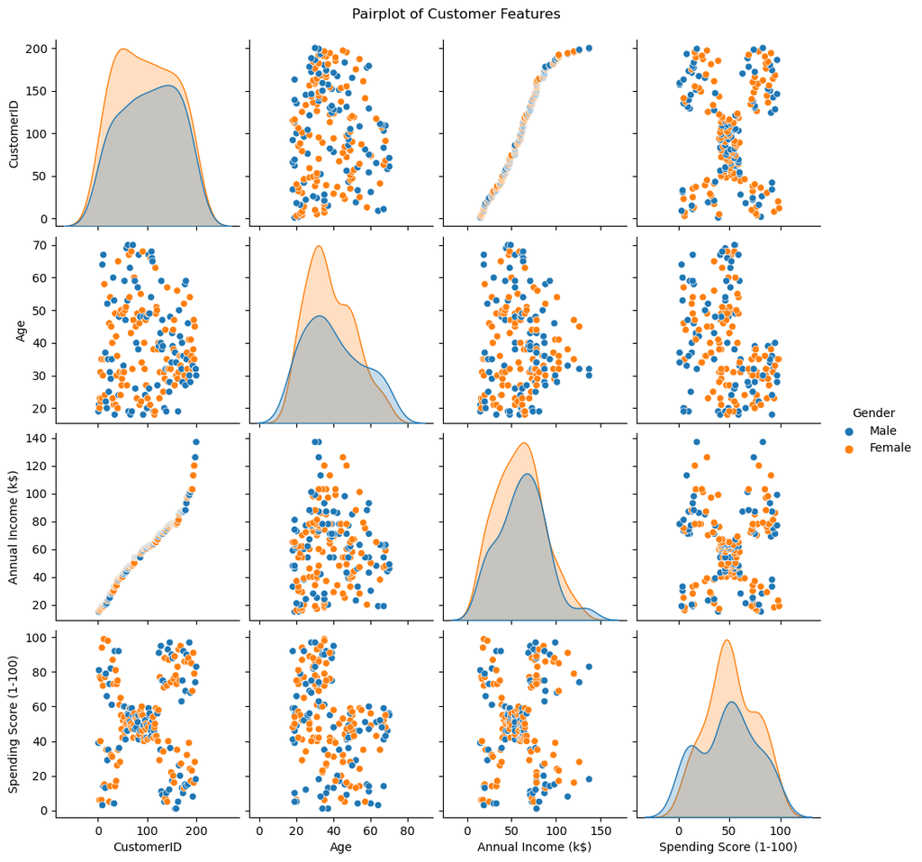

```python
import seaborn as sns
import pandas as pd
import matplotlib.pyplot as plt
df = pd.read_csv(r"C:\Users\adith\Downloads\clusteringprojectdataset.zip")
sns.pairplot(df, hue='Gender')
plt.suptitle('Pairplot of Customer Features', y=1.02)
plt.show()
```

We can generally see some clusters forming already in this pair plot. For example there seems to be 5 or so distinct clusters when comparing annual income and spending score. I now have a general idea of how many clusters there may be but I will confirm it with an elbow plot later on.

### Data Cleaning

```python
import pandas as pd
import matplotlib.pyplot as plt
import seaborn as sns
from sklearn.cluster import KMeans
from sklearn.preprocessing import StandardScaler


df = pd.read_csv(r"C:\Users\adith\Downloads\clusteringprojectdataset.zip")


print(df.head())

features = df[['Age', 'Annual Income (k$)', 'Spending Score (1-100)']]
scaler = StandardScaler()
scaled_features = scaler.fit_transform(features)
```

```
   CustomerID  Gender  Age  Annual Income (k$)  Spending Score (1-100)
0           1    Male   19                  15                      39
1           2    Male   21                  15                      81
2           3  Female   20                  16                       6
3           4  Female   23                  16                      77
4           5  Female   31                  17                      40
```

There are a few steps we have taken to clean and preprocess the data. First we made a dataframe with the features that we will use for clustering such as age income and spending score. We have also scaled the features so no one features dominates the rest and things are more equal.

### Clustering

Why are we using K-Means specifically over any other algorithms? Well because of some aspects of the dataset k-means is actually perfect for it. The features are all numeric and standardized so there is no need for any mixed type clustering or anything super complex. K-Means is also scaleable so it would work with a much larger dataset as well. But mostly K-Means solves the task at hand which is to cluster the customers. There is no need to introduce added complexity if it is not needed.

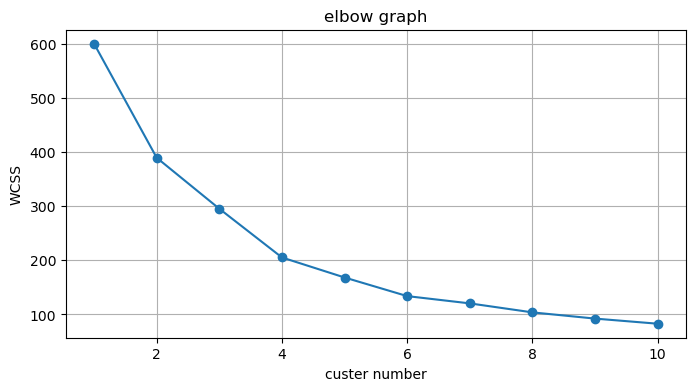

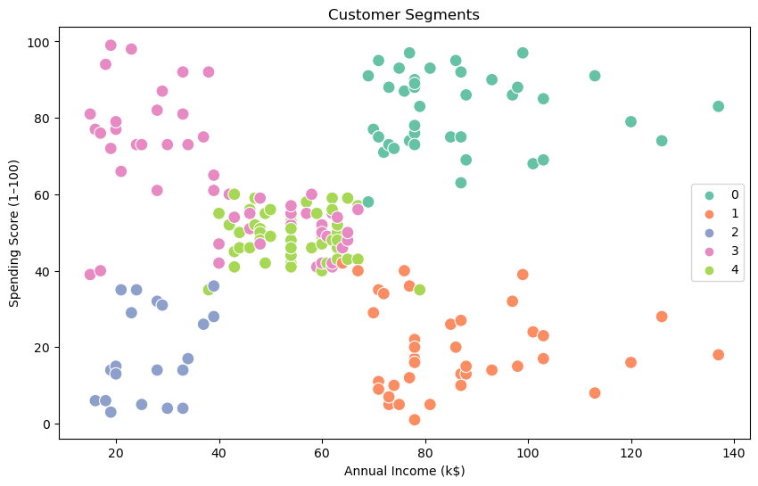

```python
wcss = []
for i in range(1, 11):
    kmeans = KMeans(n_clusters=i, random_state=42, n_init=10)
    kmeans.fit(scaled_features)
    wcss.append(kmeans.inertia_)

plt.figure(figsize=(8, 4))
plt.plot(range(1, 11), wcss, marker='o')
plt.title('elbow graph')
plt.xlabel('custer number')
plt.ylabel('WCSS')
plt.grid(True)
plt.show()

k = 5
kmeans = KMeans(n_clusters=k, random_state=47, n_init=10)
df['Cluster'] = kmeans.fit_predict(scaled_features)

plt.figure(figsize=(10, 6))
sns.scatterplot(
    x='Annual Income (k$)',
    y='Spending Score (1-100)',
    hue='Cluster',
    data=df,
    palette='Set2',
    s=100
)
plt.title('Customer Segments')
plt.xlabel('Annual Income (k$)')
plt.ylabel('Spending Score (1–100)')
plt.legend()
plt.show()
```

### Impact

There are a lot of possible ethical implications of this process. We run the risk of treating customers as just numbers and treating them as nothing more than banks to be sucked dry of every last dollar. Also the high spending and low income cluster could really be impacted very badly if the mall took advantage of them by marketing specifically to them, even though they might not be able to spend as much. We could end up targeting those who have shopping addictions, thereby worsening their conditions, as this data does not account for that sort of thing. At the end of the day is it worth it to do all of this for the bottom line?

### References

https://www.geeksforgeeks.org/k-means-clustering-introduction/

https://www.youtube.com/watch?v=4b5d3muPQmA

https://www.kaggle.com/datasets/vjchoudhary7/customer-segmentation-tutorial-in-python/data